# Decision trees and Ensemble Methods

DDD: Elements of Statistical Machine Learning & Politics of Data

Ayush Patel

At Azim Premji University, Bhopal

19 Feb, 2026

# Hello

I am Ayush.

I am a researcher working at the intersection of data, development and economics.

I am a [RStudio (Posit) certified tidyverse Instructor.](https://education.rstudio.com/trainers/people/patel+ayush/)

I am a Researcher at [Oxford Poverty and Human development Initiative (OPHI)](https://ophi.org.uk/), at the University of Oxford.

[figure not shown]

[Hello (Eh bonjour– donc–.) by Charles Motte](https://www.metmuseum.org/art/collection/search/392118%22Well)

# Did you come prepared?

- You have installed R. If not see this link.
- You have installed RStudio/Positron/VScode or any other IDE. It is recommended that you work through an IDE
- You have the libraries `{tree} {gbm} {randomForest} {BART}` installed

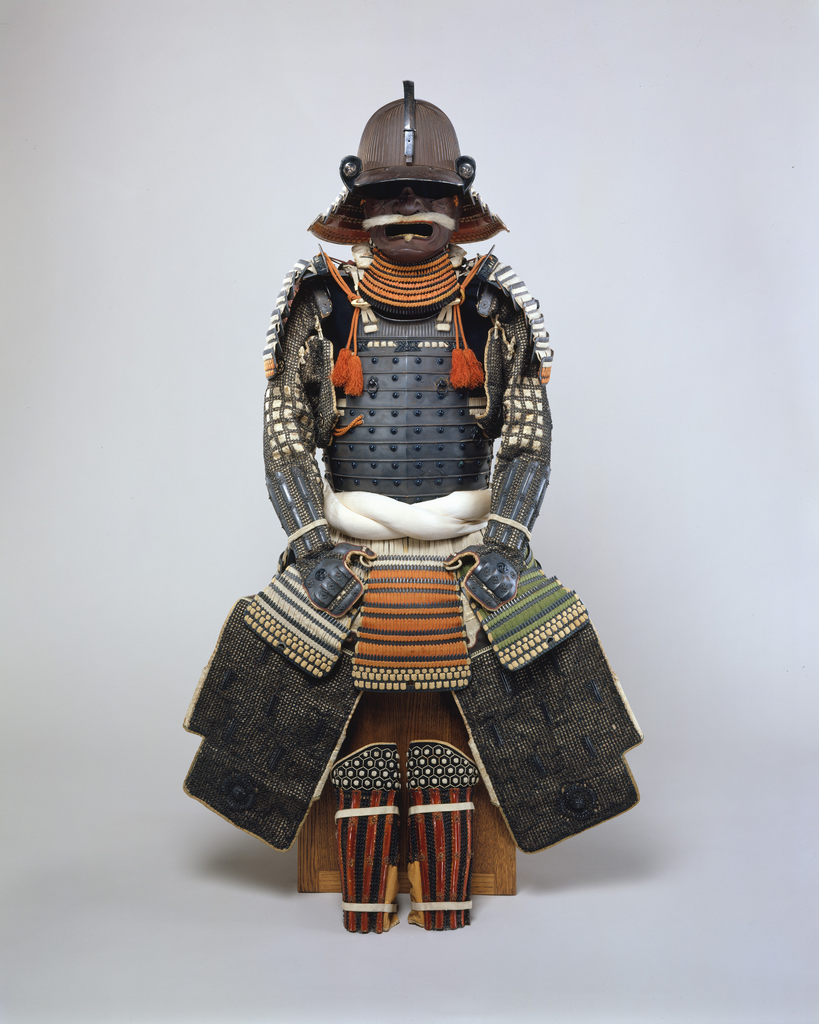

[Armor (Gusoku) Helmet signed by Bamen Tomotsugu](https://www.metmuseum.org/art/collection/search/24975)

# Learning Goals

1. What are decision trees?
2. When to use them?
3. How do these work?
4. Application and interpretation.
5. Improving decision trees using ensemble methods.

# Decision Trees

Supervised and non-parametric  
Can be used for Classification and Regression  
A predictor space is cut into segments and mean response of training observations is used as the estimate of response of test observations.  
Simple, easy to interpret but not the *best* for prediction accuracy on its own  
Prediction accuracy can be improved by ensemble methods

# Intuition - How it works

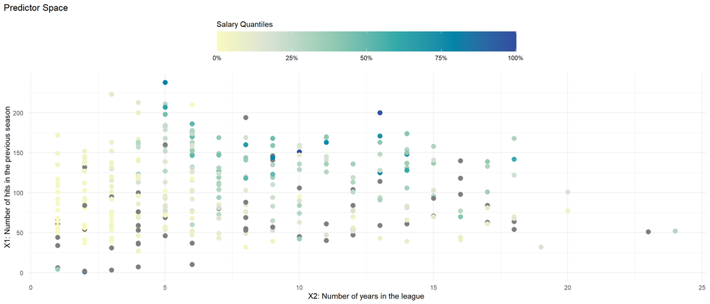

Can you Identify regions with similar salary range?

# Intuition - How it works

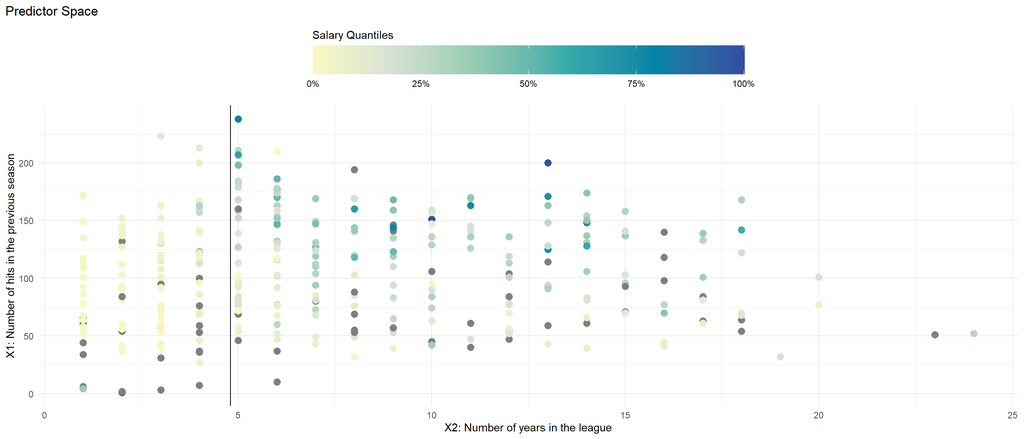

Can you Identify regions with similar salary range?

# Intuition - How it works

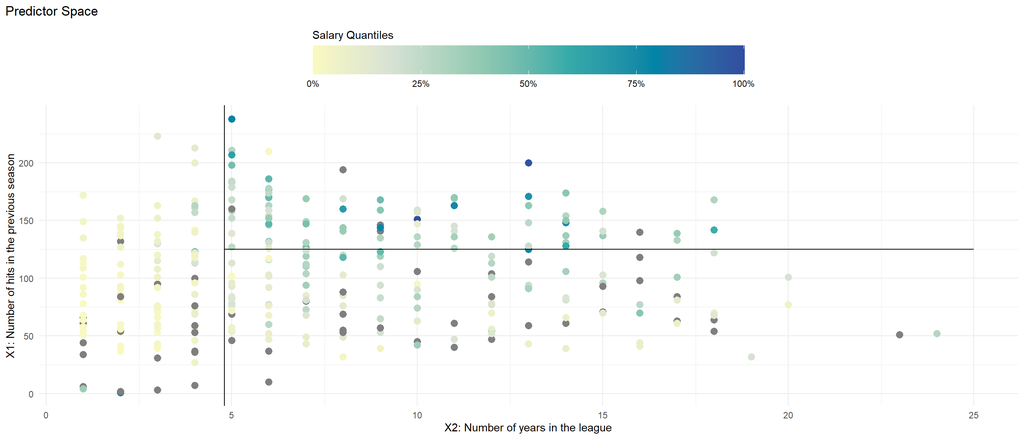

Can you Identify regions with similar salary range?

# Intuition - How it works

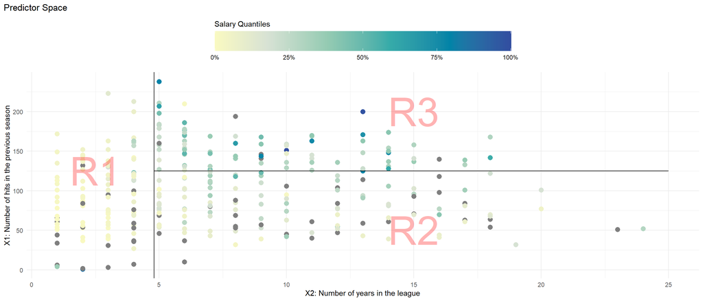

Can you Identify regions with similar salary range?

# Model output - Predictor Space

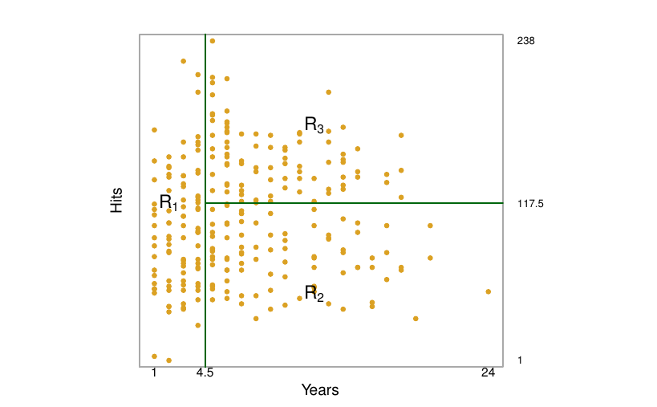

from ISLR

# Model output - Tree

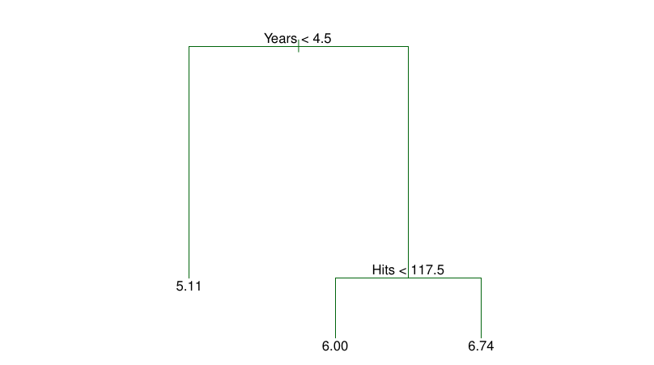

from ISLR

# Region representation

# Tree terminology

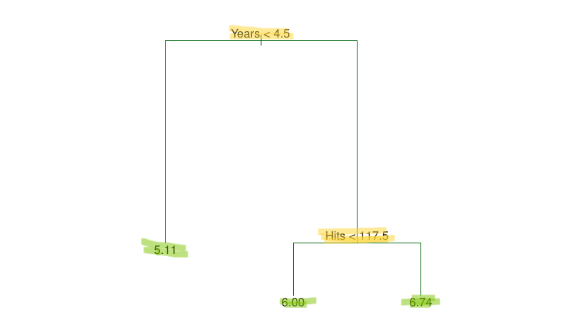

from ISLR

# How *should* we carry out segmenting of predictor space?

# Segmenting - Theory

Predictor Space of $p$ variables needs to be segmented into $J$ different regions.  
**In theory**, the regions can be of any shape, however high-dimensional rectangles are chosen in practice for computational ease and interpretability  
For every observation in region $R_j$, we make the same prediction. Mean or mode of the training observations in region $R_j$  
Minimize: $\sum_{j=1}^{J}{\sum_{i \in R_j}{(y_i - \hat{y}_{R_j})^2}}$

# But

Not easy to consider all possible cutpoints for all possible predictors with all possible sequences  
We use high-dimensional rectangles instead of any shape for ease of interpretation.

# So, use Recursive Binary splitting

*top-down*  
**greedy**

# top-down

> We brgin at the point where all observations are part of the same region. Hence the name *top-down*

# Greedy

> *Best split at a particular step.* We do not care about the future. A predictor $p$ and a cutpoint $s$ is chosen based on which split will lead to the lowest RSS.

This is carried out recursively, over and over again.

# Formally

We aim to minimize the following at every step

> $\sum_{i:x_i \in R_1 (j,s)}{(y_i - \hat{y}_{R_1})^2} + \sum_{i:x_i \in R_2 (j,s)}{(y_i - \hat{y}_{R_2})^2}$

# Fitting Regresison Trees

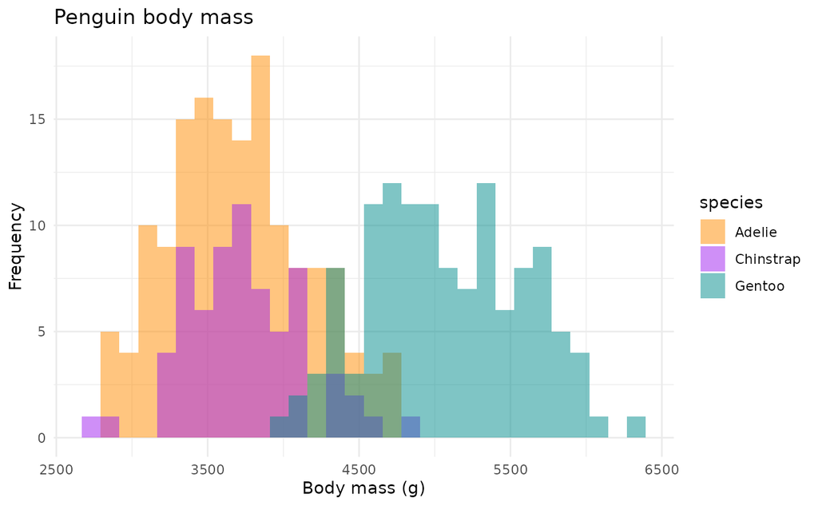

from {palmerpenguins} website

# Fitting Regresison Trees

```r
tree(body_mass_g ~ ., data = penguins) -> peng_mass_tree

peng_mass_tree
```

```
node), split, n, deviance, yval
      * denotes terminal node

1) root 333 215300000 4207
  2) species: Adelie,Chinstrap 214  40430000 3715
    4) sex: female 107   8493000 3419 *
    5) sex: male 107  13240000 4010 *
  3) species: Gentoo 119  29670000 5092
    6) sex: female 58   4519000 4680 *
    7) sex: male 61   5884000 5485 *
```

# Fitting Regression Trees

```r
peng_mass_tree$frame
```

```
      var   n       dev     yval splits.cutleft splits.cutright
1 species 333 215259666 4207.057            :ab              :c
2     sex 214  40428633 3714.720             :a              :b
4  <leaf> 107   8493224 3419.159
5  <leaf> 107  13241192 4010.280
3     sex 119  29674443 5092.437             :a              :b
6  <leaf>  58   4519321 4679.741
7  <leaf>  61   5884098 5484.836
```

# Fitting Regression Trees

```r
peng_mass_tree$where
```

```
  1   2   3   5   6   7   8  13  14  15  16  17  18  19  20  21  22  23  24  25
  4   3   3   3   4   3   4   3   4   4   3   3   4   3   4   3   4   3   4   4
 26  27  28  29  30  31  32  33  34  35  36  37  38  39  40  41  42  43  44  45
  3   4   3   3   4   3   4   3   4   3   4   4   3   3   4   3   4   3   4   3
 46  47  49  50  51  52  53  54  55  56  57  58  59  60  61  62  63  64  65  66
  4   4   3   4   3   4   3   4   3   4   3   4   3   4   3   4   3   4   3   4
 67  68  69  70  71  72  73  74  75  76  77  78  79  80  81  82  83  84  85  86
  3   4   3   4   3   4   3   4   3   4   3   4   3   4   3   4   3   4   3   4
 87  88  89  90  91  92  93  94  95  96  97  98  99 100 101 102 103 104 105 106
  4   3   4   3   3   4   3   4   3   4   3   4   3   4   3   4   3   4   3   4
107 108 109 110 111 112 113 114 115 116 117 118 119 120 121 122 123 124 125 126
  3   4   3   4   3   4   3   4   3   4   3   4   3   4   3   4   3   4   3   4
127 128 129 130 131 132 133 134 135 136 137 138 139 140 141 142 143 144 145 146
  3   4   3   4   3   4   3   4   3   4   3   4   3   4   3   4   3   4   3   4
147 148 149 150 151 152 153 154 155 156 157 158 159 160 161 162 163 164 165 166
```

[output cut: 19 more lines]

# Fitting Regression Trees

```r
summary(peng_mass_tree)
```

```
Regression tree:
tree(formula = body_mass_g ~ ., data = penguins)
Variables actually used in tree construction:
[1] "species" "sex"
Number of terminal nodes:  4
Residual mean deviance:  97680 = 32140000 / 329
Distribution of residuals:
   Min. 1st Qu.  Median    Mean 3rd Qu.    Max.
-760.30 -219.20   15.16    0.00  220.30  815.20
```

# Fitting Regression Trees

```r
plot(peng_mass_tree)
text(peng_mass_tree, pretty = 0)
```

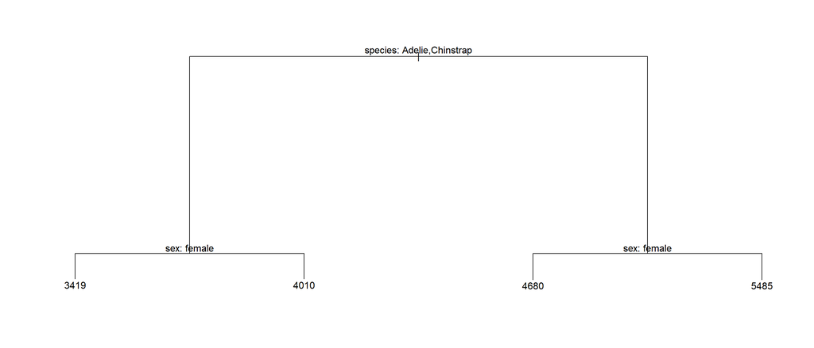

# Fitting Regression Trees

```r
na.omit(penguins) |>
    mutate(
        pred_mass = predict(peng_mass_tree)
    ) |>
        relocate(body_mass_g, pred_mass, everything())
```

```
# A tibble: 333 × 9
   body_mass_g pred_mass species island    bill_length_mm bill_depth_mm
         <int>     <dbl> <fct>   <fct>              <dbl>         <dbl>
 1        3750     4010. Adelie  Torgersen           39.1          18.7
 2        3800     3419. Adelie  Torgersen           39.5          17.4
 3        3250     3419. Adelie  Torgersen           40.3          18
 4        3450     3419. Adelie  Torgersen           36.7          19.3
 5        3650     4010. Adelie  Torgersen           39.3          20.6
 6        3625     3419. Adelie  Torgersen           38.9          17.8
 7        4675     4010. Adelie  Torgersen           39.2          19.6
 8        3200     3419. Adelie  Torgersen           41.1          17.6
 9        3800     4010. Adelie  Torgersen           38.6          21.2
10        4400     4010. Adelie  Torgersen           34.6          21.1
# ℹ 323 more rows
# ℹ 3 more variables: flipper_length_mm <int>, sex <fct>, year <int>
```

# Do it yourself

Run the linear model using the penguins data:  
$bodymass = species + sex$  
compare the RSS for the linear model with the RSS of the decision tree.

# Cant just keep splitting

some terminal nodes have very few observations

```
node), split, n, deviance, yval
      * denotes terminal node

 1) root 263 53320000  535.9
   2) CHits < 450 117  5931000  227.9
     4) AtBat < 147 5  2940000  709.5 *
     5) AtBat > 147 112  1779000  206.4
      10) CRBI < 114.5 74   302100  141.8 *
      11) CRBI > 114.5 38   567200  332.1 *
   3) CHits > 450 146 27390000  782.8
     6) Walks < 61 104  9470000  649.6
      12) AtBat < 395.5 53  2859000  510.0 *
      13) AtBat > 395.5 51  4504000  794.7
        26) PutOuts < 771 45  2358000  746.4 *
        27) PutOuts > 771 6  1255000 1157.0 *
     7) Walks > 61 42 11500000 1113.0
      14) RBI < 73.5 22  3148000  885.3
        28) PutOuts < 239.5 7  1739000 1156.0 *
        29) PutOuts > 239.5 15   656300  758.9 *
      15) RBI > 73.5 20  5967000 1363.0
        30) Years < 13.5 14  3767000 1521.0
          60) CAtBat < 3814.5 8   529600 1141.0 *
          61) CAtBat > 3814.5 6   541500 2028.0 *
        31) Years > 13.5 6  1026000  992.5 *
```

# Cant just keep splitting

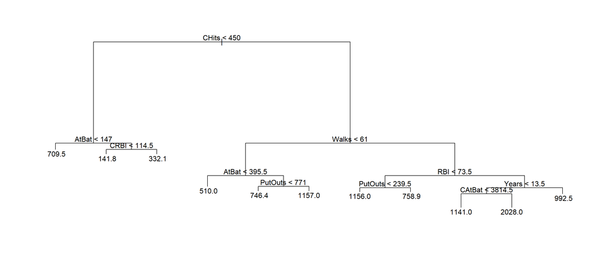

# So, when to stop

The recursive splitting approach is likely to overfit  
Leads to a complex tree  
A realtively smaller tree can avoid overfitting via lower variance. Providing better interpretation at the cost of little bias  
One could say that we split only if reduction in RSS is larger than some value. But this can be short sighted

# So what to do

Grow the full Tree.  
Prune it back to a smaller subtree  
*But which is the best subtree*  
Well, intuitively, one that leads to the lowest test error rate

# Finding the best subtree

We can use cross-validation to estimate test error rate  
But there can be so many subtrees  
So, we can select some small number of trees using cost complexity pruning or weakest link pruning

# Cost Complexity Pruning

$\sum_{m=1}^{|T|}{\sum_{i:x_i \in R_m}{(y_i - \hat{y}_{R_m})^2}} + \alpha |T|$

# The Combined Algorithm

1. Use Recursive binary splitting to grow a large tree.
2. Apply cost complexity pruning to get a sequence of best subtrees, as a function of $\alpha$
3. Use K-fold CV to choose $\alpha$.
   1. Repeat steps 1 and 2 on all but the Kth fold of training data
   2. Evaluate the mse on the left-out Kth fold, as a fucntion of $\alpha$. Average results of each value of $\alpha$, choose ove that minimizes average error.
4. Return the subtree from step 2 that corresponds with the value of chosen $\alpha$

# Step 1 - Grow the full tree

```r
rsample::initial_split(data = Hitters,prop = .75) -> hit_split
rsample::training(hit_split) -> train_tree
rsample::testing(hit_split) -> test_tree

tree(Salary ~ ., data = train_tree) -> sal_hit_tree
```

# Step 2 - Apply Cost Complexity Pruning

```r
prune.tree(sal_hit_tree)
```

```
$size
 [1] 11 10  9  8  6  5  4  3  2  1

$dev
 [1]  8315423  8703822  9215554  9858641 11662305 12847681 14633829 16914212
 [9] 22272517 36484875

$k
 [1]       -Inf   388399.2   511731.1   643087.6   901832.0  1185375.6
 [7]  1786148.6  2280382.4  5358304.9 14212358.7

$method
[1] "deviance"

attr(,"class")
[1] "prune"         "tree.sequence"
```

# Step 3 - Apply CV to choose $\alpha$

```r
cv.tree(sal_hit_tree,FUN = prune.tree) -> cv_pruned_estimates

cv_pruned_estimates
```

```
$size
 [1] 11 10  9  8  6  5  4  3  2  1

$dev
 [1] 22996997 23170872 22948306 23396461 23089788 22880520 22768324 21838163
 [9] 26519143 36994666

$k
 [1]       -Inf   388399.2   511731.1   643087.6   901832.0  1185375.6
 [7]  1786148.6  2280382.4  5358304.9 14212358.7

$method
[1] "deviance"

attr(,"class")
[1] "prune"         "tree.sequence"
```

# Step 3 - Apply CV to choose $\alpha$

```r
tibble(
    leaves = cv_pruned_estimates$size,
    rss = cv_pruned_estimates$dev
) |>
    ggplot(aes(leaves, rss)) +
    geom_point()+
    geom_line()+
    theme_minimal()
```

# Step 3 - Apply CV to choose $\alpha$

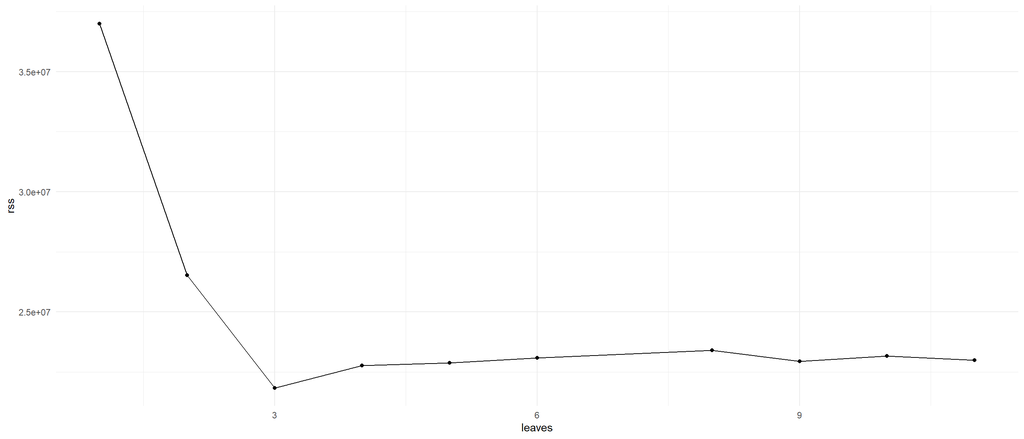

# Step 4 - get the subtree from the large tree

```r
prune.tree(sal_hit_tree, best = 3) -> best_sub_tree_sal

plot(best_sub_tree_sal)
text(best_sub_tree_sal, pretty = 0)
```

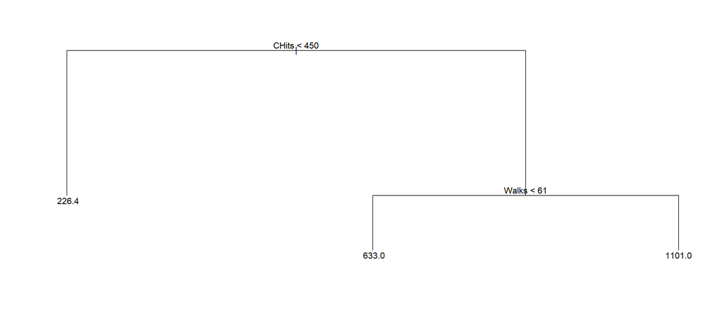

# Lets predict using the model

```r
predict(best_sub_tree_sal, test_tree)
```

```
 -Andres Galarraga   -Alfredo Griffin       -Billy Beane       -Bruce Bochy
          226.4208           633.0244           226.4208           226.4208
    -Bobby Bonilla        -Bob Brenly      -Brett Butler       -Bob Dernier
          226.4208          1101.2619          1101.2619           633.0244
     -Bill Madlock        -Bob Melvin      -Billy Sample       -Chris Bando
          633.0244           226.4208           633.0244           226.4208
  -Candy Maldonado  -Carmelo Martinez      -Chris Speier    -Curt Wilkerson
          226.4208           226.4208           633.0244           226.4208
       -Doug Baker      -Dave Collins       -Donnie Hill     -Don Mattingly
          226.4208           633.0244           226.4208           633.0244
    -Darryl Motley -Darryl Strawberry   -Danny Tartabull     -Dave Winfield
          226.4208          1101.2619           226.4208          1101.2619
      -Enos Cabell      -Eddie Milner     -Floyd Rayford       -Frank White
          633.0244           633.0244           226.4208           633.0244
      -George Bell      -Glenn Braggs       -Gary Carter   -George Hendrick
          633.0244           226.4208          1101.2619           633.0244
       -Garth Iorg   -Harold Reynolds    -Jesse Barfield    -John Cangelosi
          633.0244           226.4208          1101.2619           226.4208
     -Jose Canseco        -Julio Cruz      -Julio Franco    -Jerry Hairston
          226.4208           633.0244           633.0244           226.4208
      -Jim Presley         -Jeff Reed   -Joel Youngblood    -Kurt Stillwell
          226.4208           226.4208           633.0244           226.4208
    -Larry Herndon          -Lee Lacy      -Len Matuszek     -Lance Parrish
          633.0244           633.0244           226.4208           633.0244
      -Luis Rivera      -Larry Sheets     -Marty Barrett        -Mike Brown
          226.4208           226.4208          1101.2619           226.4208
        -Mike Diaz          -Mel Hall      -Mike Kingery     -Mike Marshall
          226.4208           226.4208           226.4208           633.0244
  -Mike Pagliarulo      -Mike Schmidt     -Milt Thompson     -Ozzie Guillen
          226.4208           226.4208           226.4208           226.4208
     -Pat Sheridan       -Rick Cerone          -Rob Deer        -Ron Kittle
          226.4208           633.0244           226.4208           226.4208
  -Rance Mulliniks      -Rey Quinones      -Ron Roenicke         -Rick Schu
          633.0244           226.4208           226.4208           226.4208
   -Robby Thompson   -Reggie Williams     -Scott Bradley    -Shawon Dunston
          226.4208           226.4208           226.4208           226.4208
     -Steve Garvey    -Tony Bernazard        -Tony Gwynn      -Tom Paciorek
          633.0244           633.0244           633.0244           633.0244
        -Tony Pena   -Terry Pendleton        -Tony Perez        -Will Clark
          633.0244           226.4208           633.0244           226.4208
 -Wayne Krenchicki
          226.4208
```

# Do it yourself

For the `Boston` data set from {ISLR2}, run a decision tree model that estimates the median value of owner-occupied homes in $1000. Complete the full algorith steps of growing a larger tree and choosing an alpha for the best possible subtree.

# Classification Trees

Response is qualitative  
For making predictions, instead of using the *mean* of the training observations in a region, the *most commonly occuring* class of training observations in a region is used.  
Classification trees are grown in a similar fashion to regression trees But, instead of RSS we use the *classification error rate*  
Classification Error Rate (E): The fraction of training observations in a region that do not belong to the most common class.

# Classification Error Rate

$$E = 1- max(\hat{p}_{mk})$$

Here $\hat{p}_{mk}$ is the proportion of training observations in the mth region of class k.  
But, this is not *sufficiently sensitive* for tree growing, so we use other measures in practice.

# Classification Error Rate - Issues

[output not shown]

[output not shown]

# Classification Error Rate - Issues

Does not favour “pure” nodes  
Only cares about the *most common class*, ignores *by how much*  
May result in premature stop in tree growing  
Insensitive to minor changes in patterns

# Alternative - Gini

$G = \sum_{k=1}^{K}{\hat{p}_{mk}(1-\hat{p}_{mk})}$  
The Value of G will be small when node purity is high.

# Alternative - Entropy

$D = - \sum_{k=1}^{K}{\hat{p}_{mk}log\hat{p}_{mk}}$  
The value of D will be near zero for $\hat{p}_{mk}$ near zero or one

# Classification Error Rate - Issues

```r
tibble::tibble(
  prop_a = seq(0,1,by = 0.001),
  prop_b = 1- prop_a,
  max = ifelse(prop_a>=prop_b, prop_a, prop_b),
  E =  1 - max,
  G = 2*(prop_a*prop_b),
  En = -1*((prop_a*log(prop_a))+(prop_b*log(prop_b)))
)  |>
  ggplot2::ggplot(ggplot2::aes(prop_a,E))+
  ggplot2::geom_line() +
  ggplot2::geom_line(ggplot2::aes(y = G), colour = "green") +
  ggplot2::geom_line(ggplot2::aes(y = En), colour = "steelblue") +
  ggplot2::theme_minimal() +
  ggplot2::labs(
    x = "probablity of Class A at a given node",
    y = "Y",
    title = "Comparing Classificaiton Error Rate, Gini and Entropy",
    subtitle = "Toy example with two classes: A and B"
  )
```

# Classification Error Rate - Issues

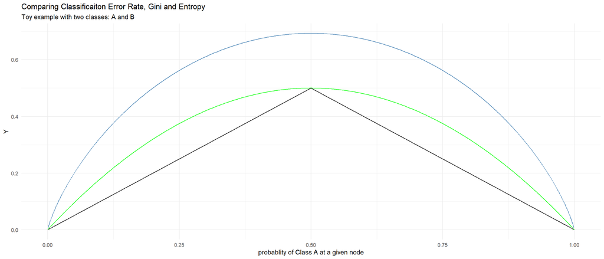

# A comment on E, G and D

Best to use G or D for splitting  
For pruning and gauging overall accuracy E is preferable if prediction accuracy is the goal.  
The {tree} takes care of all this by default

# code refrence

```r
tree(league ~ . , data = Hitters) -> mod

prune.tree(mod, method = "misclass")

cv.tree(mod, FUN = prune.misclass)
```

# Do it yourself

[This link](https://www.statlearning.com/s/Heart.csv) has the `Heart data` for paitents with chest pains. The variable `AHD` is a binary variable where `Yes` refers to existing heart disease. Create a decision tree model, a full grown tree, to understand factors for predicting `AHD`. Also, prune this tree by choosing the appropriate $\alpha$. Write an interpretation note for your model.  
Does your final and full grown trees have some splits that estimate the same response for terminal nodes? Why does that happen?

# Decision Trees

1. Easy to interpret
2. Can handle qualitative as well as quantitative response
1. Not as great for prediction accuracy as some other regression or classification approaches.
2. Small changes in training data can lead to large chanages in the final estimated tree.

# Aggregating many trees can imporve performance (prediction)

Ensemble Mehtods: Bagging, random forests, boosting, and Bayesian additive regression trees.

# Ensemble Methods

Combine many simple models to get one powerful model  
These simple models are sometimes known as *weak learners*

# Bagging

Remember *Bootstrap*?  
Can be used to estimate the SD of the quantity of interest where it is hard or impossible to directly compute it.  
Can be also used to imporve statistical learning models like decision trees

# Bagging - before we get into it

> “*Averaging a set of observations reduces variance*”

# Bagging - before we get into it

> Imagine a natural process that generates $n$ observation $Z_1, Z_2, ...,Z_n$ with Variance $\sigma^2$. Stats says that the variance of $\bar{Z}$ is $\frac{\sigma^2}{n}$

```r
rnorm(n = 100,mean = 5,sd = 10) -> Z_i

Z_i
```

```
  [1]  -8.1360861  -4.1391838  10.2449012 -11.3087422  20.8666062   0.4471373
  [7]  -3.9211056   9.4314274  -3.7776722  15.3119345 -13.7413027   2.8374375
 [13]   4.5242641   1.6853593  31.6339853  18.3211858   0.8447623   4.3790233
 [19]  -7.0520856  20.5189606 -15.0999019   2.0845359  -1.7718203  14.1652564
 [25]   3.4638982  11.9859692  17.9148233   8.6347894  -6.1741353   3.7894257
 [31]  10.0947444 -13.9006288   5.5033750 -24.1739753   5.7505045   2.7501970
 [37]  15.9996548   3.9403011  -5.6197091   8.7986218   2.2780200  -7.4100327
 [43]  18.4976936  -8.6490931   6.2743414 -11.7791600 -17.4996825   3.1568829
 [49]   2.6512777  19.0479422 -20.5441292  13.5861305   6.4453418   9.5961700
 [55]  19.4935179 -11.2905350  14.0204028   3.6480383  -6.6890601  -1.8238145
 [61]  -6.9898029   6.3329664 -15.0546166   2.5597589   0.7187514  21.9757056
 [67]   7.4627163  10.8819883  20.3690047   6.1189416   4.7142081  13.2569965
 [73]  26.7099814   4.2181417  10.0992709   1.9650511  11.3410040   7.4235442
 [79]  11.6950879  14.3422891  20.5732724  24.6022092  -0.2352916  -6.4954831
 [85]  18.8712865 -13.8541651  30.4268314  -6.8789036   9.1495597  -5.9847670
 [91]  11.7743394  10.1918240  21.2279810   1.2142288   8.9618899   0.9281606
 [97]  11.2491975   3.3487586  20.8326771   0.1807221
```

```r
var(Z_i)
```

```
[1] 131.4922
```

# Bagging - before we get into it

I estimate the variance of mean, it should be ($\frac{\sigma^2}{n}$)

```r
purrr::map_dbl(
  c(1:100),
  ~ rnorm(n = 100, mean = 5, sd = 10) |>
    mean()
) |> var()
```

```
[1] 1.148222
```

# Bagging - before we get into it

I estimate the distribution of variance of mean, it should be *centered* around ($\frac{\sigma^2}{n}$)

```r
purrr::map_dbl(
    c(1:1000),
    ~purrr::map_dbl(
  c(1:100),
  ~ rnorm(n = 100, mean = 5, sd = 10) |>
    mean()
) |> var()
) |>
    density()|>
    plot("Distribution of the variance of mean")
```

# Bagging - before we get into it

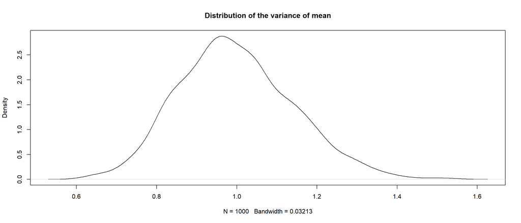

# Bagging - before we get into it

> So, averaging stuff reduces the variance, we can be sure. Natuarally, we can reduce the variance of a statistical learning methods by averaging.

# Bagging

So, take multiple training sets  
Grow a full tree for each training sets  
Average the resulting predictions  
$\hat{f}_{avg} = \frac{1}{B}\sum_{b=1}^{B}{\hat{f}^b}$  
But I dont ahve so much training data

# Bagging

So, Bootstrap. Bootstrap + Aggregating = Bagging

$\hat{f}_{bag} = \frac{1}{B}\sum_{b=1}^{B}{\hat{f}^{*b}}$

# Bagging

These trees are grown deep  
Not Pruned  
So each individual tree has high variance and low bias.  
Averaging the trees reduces the variance  
In classification setting we use majority vote instead of average

# Bagging - How well it performs?

> I want to compare the Bagging test error rate with the unpruned single tree test error rate and pruned single tree test error rate.

# Bagging - How well it performs?

I will use the orange juice data set to work this example

```
Rows: 1,070
Columns: 18
$ Purchase       <fct> CH, CH, CH, MM, CH, CH, CH, CH, CH, CH, CH, CH, CH, CH,…
$ WeekofPurchase <dbl> 237, 239, 245, 227, 228, 230, 232, 234, 235, 238, 240, …
$ StoreID        <dbl> 1, 1, 1, 1, 7, 7, 7, 7, 7, 7, 7, 7, 7, 7, 7, 7, 1, 2, 2…
$ PriceCH        <dbl> 1.75, 1.75, 1.86, 1.69, 1.69, 1.69, 1.69, 1.75, 1.75, 1…
$ PriceMM        <dbl> 1.99, 1.99, 2.09, 1.69, 1.69, 1.99, 1.99, 1.99, 1.99, 1…
$ DiscCH         <dbl> 0.00, 0.00, 0.17, 0.00, 0.00, 0.00, 0.00, 0.00, 0.00, 0…
$ DiscMM         <dbl> 0.00, 0.30, 0.00, 0.00, 0.00, 0.00, 0.40, 0.40, 0.40, 0…
$ SpecialCH      <dbl> 0, 0, 0, 0, 0, 0, 1, 1, 0, 0, 0, 0, 0, 0, 0, 0, 0, 0, 0…
$ SpecialMM      <dbl> 0, 1, 0, 0, 0, 1, 1, 0, 0, 0, 0, 0, 1, 0, 0, 0, 1, 1, 0…
$ LoyalCH        <dbl> 0.500000, 0.600000, 0.680000, 0.400000, 0.956535, 0.965…
$ SalePriceMM    <dbl> 1.99, 1.69, 2.09, 1.69, 1.69, 1.99, 1.59, 1.59, 1.59, 1…
$ SalePriceCH    <dbl> 1.75, 1.75, 1.69, 1.69, 1.69, 1.69, 1.69, 1.75, 1.75, 1…
$ PriceDiff      <dbl> 0.24, -0.06, 0.40, 0.00, 0.00, 0.30, -0.10, -0.16, -0.1…
$ Store7         <fct> No, No, No, No, Yes, Yes, Yes, Yes, Yes, Yes, Yes, Yes,…
$ PctDiscMM      <dbl> 0.000000, 0.150754, 0.000000, 0.000000, 0.000000, 0.000…
$ PctDiscCH      <dbl> 0.000000, 0.000000, 0.091398, 0.000000, 0.000000, 0.000…
$ ListPriceDiff  <dbl> 0.24, 0.24, 0.23, 0.00, 0.00, 0.30, 0.30, 0.24, 0.24, 0…
$ STORE          <dbl> 1, 1, 1, 1, 0, 0, 0, 0, 0, 0, 0, 0, 0, 0, 0, 0, 1, 2, 2…
```

# Bagging - How well it performs?

**Steps**

1. Split data in training and test.
2. On the training data grow a decision tree for classification. (Mod1)
3. Find the error rate of Mod1 on test data.
4. Prune the Mod1 by finding $\alpha$ through CV. Call this model Mod2.
5. Find error rate of Mod2 on test data.
6. Split the training data in 300 bootstrap samples. Grow a tree for each of the 300 samples.
7. Using all 300 trees predict error rate for test data. (Bagging test error rate)
8. Do point 7 sequentially to show how Bagging test error rate changes with number of bootstrap samples.(E by using Bootstrap sample 1 only, then with 1 and 2, then 1 to 3, till 1 to 300)

# Bagging - How well it performs?

**Step1**: Split data in training and test.

```r
rsample::initial_split(data = OJ, prop = .9) -> oj_split
rsample::training(oj_split) -> oj_train
rsample::testing(oj_split) -> oj_test
```

# Bagging - How well it performs?

**Step2**: On the training data grow a decision tree for classification. (Mod1)

```r
tree(Purchase ~., oj_train) -> Mod1
```

# Bagging - How well it performs?

**Step3**: Find the error rate of Mod1 on test data.

```r
Mod1_test_error <- sum(
    predict(Mod1, oj_test, "class") != oj_test$Purchase
    )/107
```

# Bagging - How well it performs?

**Step4**: Prune the Mod1 by finding $\alpha$ through CV. Call this model Mod2.

```r
map(
    c(1:100),
    ~tibble(
        size = cv.tree(Mod1,FUN = prune.misclass)[["size"]],
        e = cv.tree(Mod1,FUN = prune.misclass)[["dev"]]
    )
) |>
    list_rbind()|>
    group_by(size) |>
    summarise(
        mean_e = mean(e, na.rm = T)
    )
```

```
# A tibble: 5 × 2
   size mean_e
  <int>  <dbl>
1     1   380.
2     2   203.
3     4   187.
4     7   179.
5     9   179.
```

```r
prune.tree(Mod1,best = 4) -> Mod2
```

# Bagging - How well it performs?

**Step5**: Find error rate of Mod2 on test data

```r
Mod2_test_error <- sum(
    predict(Mod2, oj_test, "class") != oj_test$Purchase
    )/107
```

# Bagging - How well it performs?

**Step6&7**: Split the training data in 300 bootstrap samples. Grow a tree for each of the 300 samples. Using all 300 trees predict error rate for test data. (Bagging test error rate)

```r
rsample::bootstraps(oj_train,times = 300) -> oj_train_boot

get_dist_error_test_set <- function(i){

    tree(Purchase ~ ., data = rsample::get_rsplit(oj_train_boot,index = i) |>
    as.data.frame()
        ) -> tree_oj

    tibble(
        "b_{i}" := predict(tree_oj, oj_test, "class")
    )

}

map(
    c(1:300),
    get_dist_error_test_set
) |>
    list_cbind() -> boot_predicts

boot_predicts |>
    as.matrix() |>
    t() |>
    as.data.frame() -> boot_predicts

boot_predicts
```

[output not shown]

[output cut: 1751 more lines]

[output not shown]

# Bagging - How well it performs?

**Step8**: Do point 7 sequentially to show how Bagging test error rate changes with number of bootstrap samples.(E by using Bootstrap sample 1 only, then with 1 and 2, then 1 to 3, till 1 to 300)

```r
across_boots_acc <- function(i) {

    boot_predicts[c(1:i),] |>
    summarise(across(everything(),~ attr(sort(table(.x),decreasing = T)[1],"name"))) |>
    t() |>
    as.vector() -> boot_predicts

    sum(boot_predicts == oj_test$Purchase, na.rm = T)/107

}

tibble(
    num_boots = c(1:300),
    bagg_test_error = 1-(map_dbl(
    c(1:300),
    across_boots_acc))
) |>
    ggplot(aes(x = num_boots, y = bagg_test_error)) +
    geom_line(colour = "steelblue")+
    geom_hline(aes(yintercept = Mod1_test_error),
    linetype = 2, colour = "red")+
    annotate(geom = "text",
    label = "Unpruned single tree Test error rate",
    x = 275, y = Mod1_test_error, colour = "red")+
    geom_hline(aes(yintercept = Mod2_test_error),
    linetype = 2, colour = "red")+
    annotate(geom = "text",
    label = "pruned single tree Test error rate",
    x = 275, y = Mod2_test_error, colour = "red")+
    labs(
        title = "Comparing test error rate estimates",
        x = "Number of bootstrap samples",
        y = "Error",
        subtitle = "Plot shows: <span style='color:steelblue;'>Bagging test error rate.</span>"
    )+
    theme_minimal() +
    theme(
        plot.title.position = "plot",
        plot.subtitle = element_markdown()
    )
```

# Bagging - How well it performs?

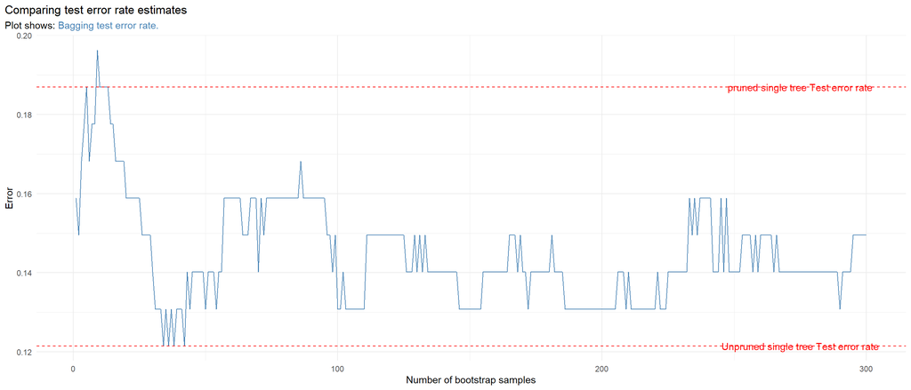

# Bagging

> Why are we wasting samples to get an estimate of test error rate? There is a way *Out-of-Bag Error Estimation*.

# Bagging - Out-of-Bag Error Estimation

1. On an average each bagged tree uses only 2/3 rd of the observations.
2. This would mean that there are 1/3 rd observations which are not used to fit a given bagged tree. These are called “Out-of-Bag” or OOB.
3. A given *i*th OOB observation can be predicted using B/3 trees. (By average or mode)
4. This can be achieved for all OOB observations.
5. These predictions for OOB can be compared against true values to obtain OOB MSE.
6. OOB MSE is a valid estimate of test error for the bagged model.

# Bagging error rate estimates

```r
randomForest::randomForest(Purchase ~. , OJ,mtry = 17) -> bag_oj

tibble(
    num_boots = c(1:300),
    bagg_test_error = 1-(map_dbl(
    c(1:300),
    across_boots_acc)),
    oob_mse = bag_oj$err.rate[c(1:300),"OOB"]
) |>
    ggplot(aes(x = num_boots, y = bagg_test_error)) +
    geom_line(colour = "steelblue")+
    geom_line(aes(y = oob_mse),
    colour = "green") +
    geom_hline(aes(yintercept = Mod1_test_error),
    linetype = 2, colour = "red")+
    annotate(geom = "text",
    label = "Unpruned single tree Test error rate",
    x = 275, y = Mod1_test_error, colour = "red")+
    geom_hline(aes(yintercept = Mod2_test_error),
    linetype = 2, colour = "red")+
    annotate(geom = "text",
    label = "pruned single tree Test error rate",
    x = 275, y = Mod2_test_error, colour = "red")+
    labs(
        title = "Comparing test error rate estimates",
        x = "Number of bootstrap samples",
        y = "Error",
        subtitle = "Plot shows: <span style='color:steelblue;'>Bagging test error rate.</span>, <span style='color:green;'>OOB MSE - Bootstrap</span>"
    )+
    theme_minimal() +
    theme(
        plot.title.position = "plot",
        plot.subtitle = element_markdown()
    )
```

# Bagging error rate estimates

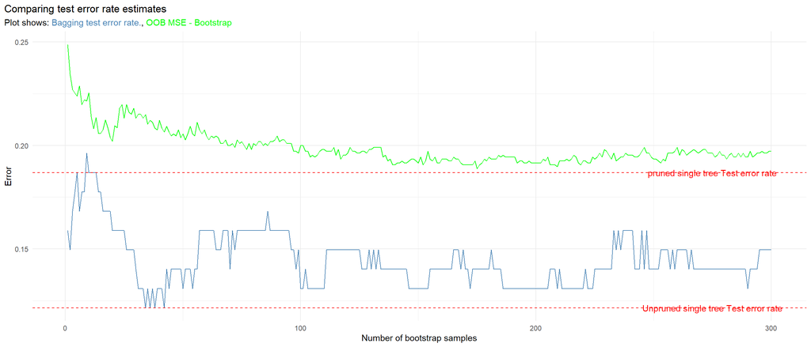

# Bootstrap and interpretation

# Bootstrap - VIM

|  | MeanDecreaseGini |
| --- | --- |
| WeekofPurchase | 50.6880866 |
| StoreID | 14.2745194 |
| PriceCH | 5.6401013 |
| PriceMM | 5.4588747 |
| DiscCH | 2.5397152 |
| DiscMM | 2.8236487 |
| SpecialCH | 7.6629707 |
| SpecialMM | 2.9617345 |
| LoyalCH | 305.3815921 |
| SalePriceMM | 13.6102313 |
| SalePriceCH | 6.7420401 |
| PriceDiff | 41.9907270 |
| Store7 | 0.2618477 |
| PctDiscMM | 3.4179647 |
| PctDiscCH | 3.4098449 |
| ListPriceDiff | 19.8971657 |
| STORE | 13.2372115 |

# Bootstrap - VIM

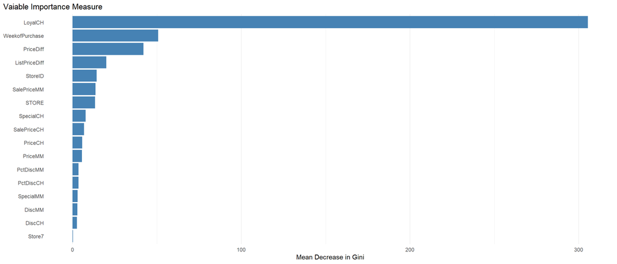

# Random Forest

In bagging, though the training observations changes, most trees will look more or less alike. Especially of one of the predictors can very strongly predict the response, with other predictors that moderately precidt the response.  
This makes us question independence of the bootstrap predictions  
And, if independence is not observed, averaging does not reduce the variance. Consequently, the bagging may not result in substantial reduction in the variance of the method.  
So we decorelate the trees by forcing to use only $m$ of the $p$ predictor at every given split of every tree. usually $m = \sqrt{p}$

# Random Forest OOB MSE

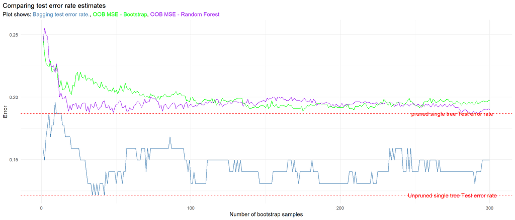

# Application: Bootstraping

```r
randomForest(Purchase ~ ., data = OJ, mtry = 17)
```

```
Call:
 randomForest(formula = Purchase ~ ., data = OJ, mtry = 17)
               Type of random forest: classification
                     Number of trees: 500
No. of variables tried at each split: 17

        OOB estimate of  error rate: 20.19%
Confusion matrix:
    CH  MM class.error
CH 541 112   0.1715161
MM 104 313   0.2494005
```

# Application: Random Forest

```r
randomForest(Purchase ~ .,  data = OJ, mtry = 4)
```

```
Call:
 randomForest(formula = Purchase ~ ., data = OJ, mtry = 4)
               Type of random forest: classification
                     Number of trees: 500
No. of variables tried at each split: 4

        OOB estimate of  error rate: 19.35%
Confusion matrix:
    CH  MM class.error
CH 563  90   0.1378254
MM 117 300   0.2805755
```

# Do it yourself

1. Goal: Use `cells` from {modeldata} to predict the `class` variable.
2. Drop the `case` variable before doing any modeling.
3. Find the test set error rate of single unpruned tree.
4. Find the test set error rate for a single pruned tree with cost complexity pruning.
5. Find OOB MSE of the bagging model.
6. Find OOB MSE of the random forest model.
7. explore model objects in points 5 and 6.
8. Make chart comparing test error rate estimation from points 3,4,5,and 6.

# Boosting

Does not involve bootstraping  
Instead, trees are grown sequentially. Each tree is grown from information from the previous tree.  
So, boosting trees are not independent of each other  
Learning slowly avoids overfitting

# Boosting Algorithm

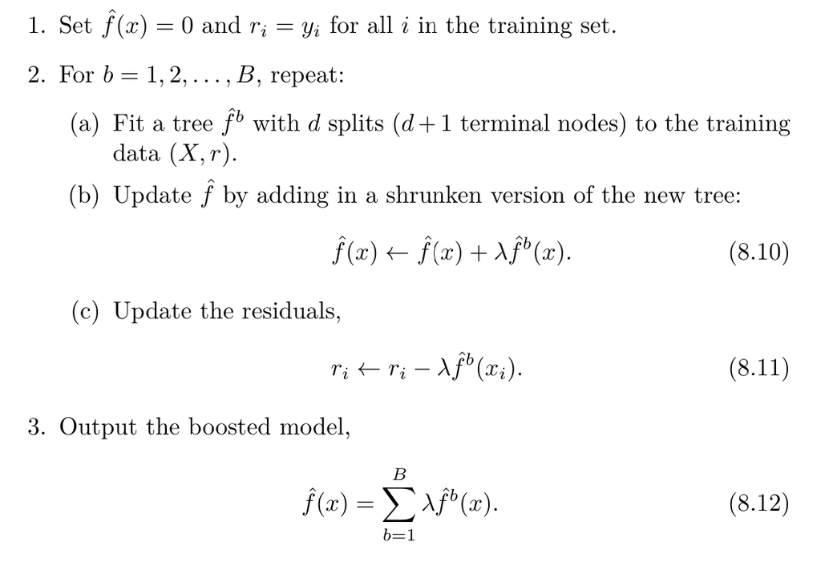

from ISLR

# Boosting - params

**Shrinkage Parameter $\lambda$**: Small positive number. Controls the rate at which boosting learns. Very small $\lambda$ can need a very large number of B to get good performance. Usual values are 0.01 or 0.001

**Depth $d$**: Controls the complexity of the boosted ensemble. Ususal d values are 1,4,6,8 depending on data. Also controls the possibility for interaction. Also referred to *interaction depth*

# Applying Boosting

```r
library(gbm)
initial_split(Boston,prop = .7) -> Boston_split
training(Boston_split) -> Boston_train
testing(Boston_split) -> Boston_test

boost.bostom <- gbm(medv ~ .,
data = Boston_train,
distribution = "gaussian",
n.trees = 5000,
interaction.depth = 4
)

boost.bostom
```

```
gbm(formula = medv ~ ., distribution = "gaussian", data = Boston_train,
    n.trees = 5000, interaction.depth = 4)
A gradient boosted model with gaussian loss function.
5000 iterations were performed.
There were 12 predictors of which 12 had non-zero influence.
```

# Applying Boosting

```
            var    rel.inf
rm           rm 39.5004210
lstat     lstat 31.6813062
crim       crim  7.4402849
dis         dis  5.8450487
nox         nox  5.3256192
ptratio ptratio  3.4673820
age         age  3.3567731
tax         tax  1.4056926
chas       chas  0.6330857
indus     indus  0.6156968
rad         rad  0.5248097
zn           zn  0.2038801
```

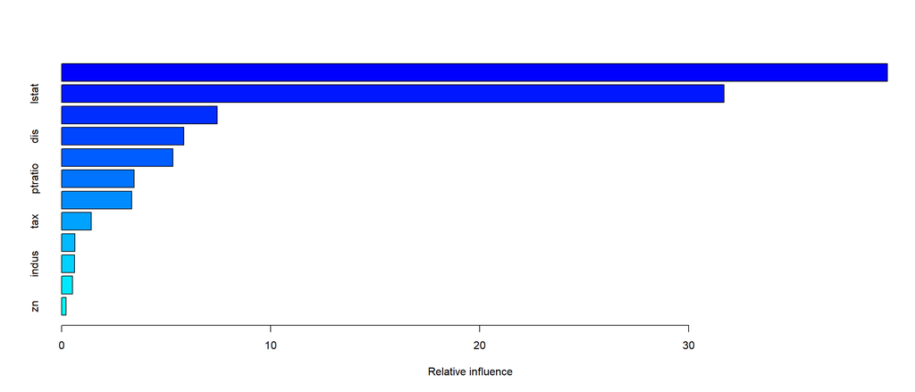

# Applying Boosting

Partial dependence plots

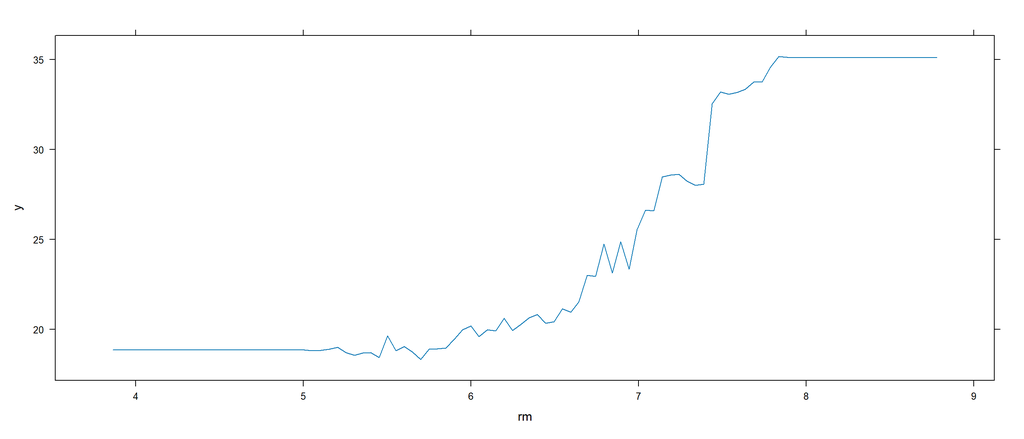

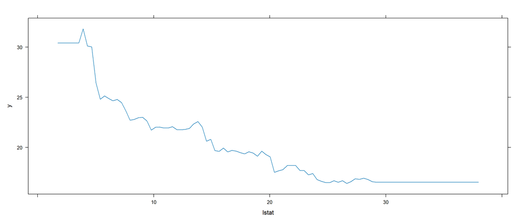

```r
plot(boost.bostom, i = "rm")
plot(boost.bostom, i = "lstat")
```

# Applying Boosting

```r
predict(boost.bostom, Boston_test) -> y_hat

mean((y_hat - Boston_test$medv)^2, na.rm = T)
```

```
[1] 19.07684
```

# Applying Boosting

```r
boost.bostom <- gbm(medv ~ .,
data = Boston_train,
distribution = "gaussian",
n.trees = 5000,
interaction.depth = 4,
shrinkage = 0.2, # control for lambda
verbose = F
)

predict(boost.bostom, Boston_test) -> y_hat

mean((y_hat - Boston_test$medv)^2, na.rm = T)
```

```
[1] 18.16881
```

# Applying Boosting

```r
boost.bostom <- gbm(medv ~ .,
data = Boston_train,
distribution = "gaussian",
n.trees = 5000,
interaction.depth = 4,
cv.folds = 100
)

gbm.perf(boost.bostom, method = "cv")
```

```
[1] 168
```

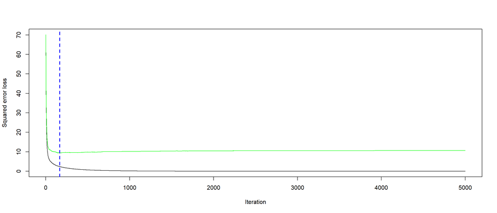

# Boosting vs RF

```r
randomForest(medv ~. , Boston, mtry = 3, ntree = 5000) -> rf_bosotn

tibble(
    i = c(1:5000),
    boost_mse = boost.bostom$cv.error,
    rf_mse = rf_bosotn$mse
) |>
    ggplot(aes(i,boost_mse))+
    geom_line()+
    geom_line(aes(y = rf_mse), colour = "red") +
    labs(
        x = "Number of trees",
        y = "MSE"
    )+
    ylim(8,15)+
    theme_minimal()
```

# Boosting vs RF

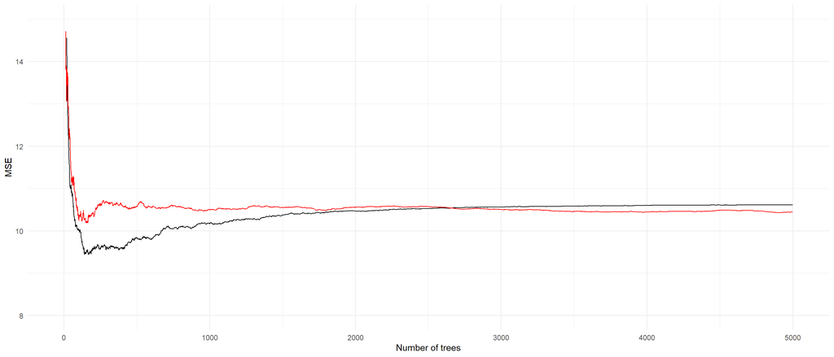

# Do it yourself

Use the `ischemic_stroke` data from modeldata library. Predict `stroke`. Compare Boosting with randomforest. What are the optimal number of boosting trees? Which model performs better? Which are the important variables.

# Bayesian Additive Regression Trees (BART)

> BART is related to both approaches. Growing trees randomly as well as growing tres where each tree tries to capture the signal not yet accounted by the current model.

# Bayesian Additive Regression Trees (BART)

We grow a total of $K$ trees over $B$ iterations  
Such that, $\hat{f}_k^b(x)$ represents the prediction at $x$ by the kth tree of the bth iteration  
All trees of a given iteration are summmed to get:  
$\hat{f}^b = \sum_{k=1}^{K}{\hat{f}_k^b(x)}$

# Bayesian Additive Regression Trees (BART)

For the first iteration, we set the trees in a manner such that sum of the trees in the first iteration comes out to the mean of the response.  
$\hat{f}^1 = \sum_{k=1}^{K}{\hat{f}_{k}^1}=\frac{1}{n}\sum_{i=1}^{n}{y_i}$  
All trees of the first iteration are initialised to have a single root node, described by:  
$\hat{f}_{k}^{1} = \frac{1}{nK}\sum_{i=1}^{n}{y_i}$

# Bayesian Additive Regression Trees (BART)

For subsequent iterations, Each K trees are updated one at a time.  
Instead of fitting a fresh tree, BART randomly chooses a perturbation (disturbance) to the tree from the previous iteration $\hat{f}_{k}^{b-1}$  
This perturbation could be either (A) increasing or pruning the branches or (B) change the prediction of each terminal node of the tree  
The trees are fit on partial residuals, described as  
$r_i = y_i - \sum_{k^{\prime} < k}{\hat{f}_{k^{\prime}}^{b}(x_i)} - \sum_{k^{\prime} > k}{\hat{f}_{k^{\prime}}^{b-1}(x_i)}$

# Bayesian Additive Regression Trees (BART)

The output of BART is a collection of prediction models

$\hat{f}^{b} = \sum_{k=1}^{K}{\hat{f}_{k}^{b}(x)}$ for $b = 1,2,3,4....., B$

# Bayesian Additive Regression Trees (BART)

The first few of these prediction models are thrown out, denoted by $L$, the burn-in period  
To obtain single prediciton  
$\hat{f}(x)=\frac{1}{B-L}\sum_{b = L+1}^{B}{\hat{f}^{b}(x)}$  
[Instead of averages, percentils can also be used to measure uncertainity.]

# Bayesian Additive Regression Trees (BART)

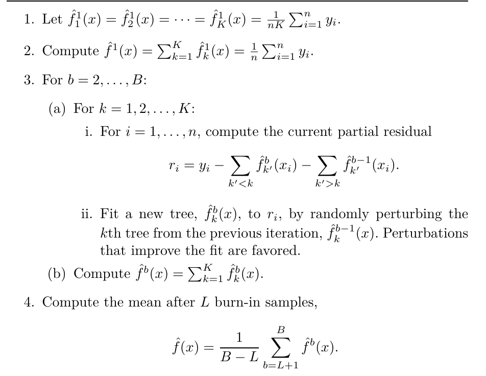

from ISLR

# Bayesian Additive Regression Trees (BART)

Parameters to select  
$K$, The number of trees  
$B$, the number of iterations  
$L$, the burn-in iterations

# Applying BART

```r
library(BART)

gbart(
    x.train = Boston_train[,1:12],
    y.train = Boston_train[,"medv"],
    x.test = Boston_test[,1:12]
) ->  bart_boston
```

[output not shown]

```r
# bart_boston$yhat.test

mean((Boston_test$medv - bart_boston$yhat.test.mean)^2)
```

```
[1] 18.29006
```

# Applying BART

A sort of variable importance, occurence of each predictor in collection of trees

```
   crim      zn     dis     age   indus ptratio     tax     rad      rm    chas
 11.257  16.339  17.057  17.111  18.160  19.990  21.520  21.885  22.399  22.464
  lstat     nox
 23.541  23.805
```

# Applying BART

`ntree` to control for $K$  
`nskip` to control for $L$  
`ndpost` to control for $B-L$